# Transcriptomic Profiling Across Developmental Stages of T. californicus: Preprocessing, Mapping, and Gene Counts

Kevin Olsen

**Project objective: Evaluate gene expression patterns across stages of ontogenetic development in the intertidal copepod Tigriopus californicus using bulk RNA-sequencing.**

**Goal of this html: Conduct preprocessing of paired-end reads generated from Illumina Stranded mRNA Prep and 150 bp sequencing on a NovaSeq 6000 at the University of California San Diego’s IGM Genomics Center.**

Developmental stages included (total n = 16 bulk RNA-seq libraries):

- Newly hatched nauplii larvae (less than 2 hours post-hatching, n = 3 libraries)
- Late nauplii (pre-metamorphosis, Day 6 - 8 post-hatching, n = 4 libraries)
- Juvenile copepodid (post-metamorphosis, Day 7 - 9 post-hatching, n = 3 libraries)
- Adult Female (Day 21 post-hatching, n = 3 libraries)
- Adult Male (Day 21 post-hatching, n = 3 libraries)
  $$\\[0.15in]$$
  **Broadly, steps include:**
1. Concatenate reads from libraries sequenced on multiple lanes.
2. Remove Nextera sequencing adapters and conduct filtering of reads with low quality.
3. Align reads to the T. californicus reference genome (SDv2.2).
4. Generate gene counts for each sample (i.e., library).
5. Collate gene counts for subsequent analyses.
   $$\\[0.15in]$$
   **Samples were extracted, libraries were prepped and sequenced in two batches (Sept_5_23 and Oct_4_23).**

The Oct_4_23 samples were sequenced on four lanes and need to be concatenated. The Sept_5_23 samples were sequenced on individual lanes and do not need concatenating.

Generate a bash script to automate concatenating of Oct_4_23 samples.

```bash
##create concatenate script in present working directory
nano ./concat_script.sh
```

For each unique sample in the Oct_4_23 subdirectory (e.g., Late_nauplii_7, Late_nauplii_9, etc.), concatenate the four sets of forward reads into a single forward (R1) FASTQ and concatenate the four sets of reverse reads into a single reverse (R2) FASTQ.

```bash
#!/bin/bash

path_fastq="<PATH>/Oct_4_23/Original_FASTQs/"

##make list of unique sample names to iterate over. Cut path prefix and lane info suffix
ls $path_fastq*_R1_* | cut -f11 -d/ | cut -f1-3 -d_ | sort -u > sample_names

##for each unique sample, concatenate forward reads
for i in `cat ./sample_names`; do cat $path_fastq"$i"_S9*_L00*_R1_001.fastq.gz > $path_fastq/concat_FASTQs/"$i"_R1_001.fastq.gz
done

##for each unique sample, concatenate reverse reads
for i in `cat ./sample_names`; do cat $path_fastq"$i"_S9*_L00*_R2_001.fastq.gz > $path_fastq/concat_FASTQs/"$i"_R2_001.fastq.gz
done
```

Execute concatenate script.

```bash
##make concatenate script executable
chmod +x ./concat_script.sh

##execute concatenate script
./concat_script.sh
```

$$\\[0.15in]$$
**FASTQC of concatenated reads indicated the presence of Nextera adapters, excess polyG sequences, and 1st base pair with low quality scores.**

- Sample Late_nauplii_7 as an example:

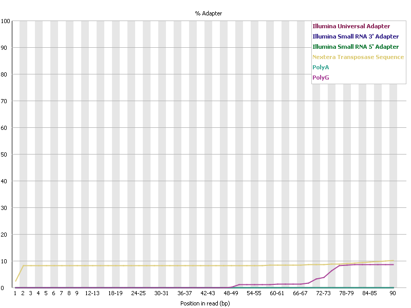

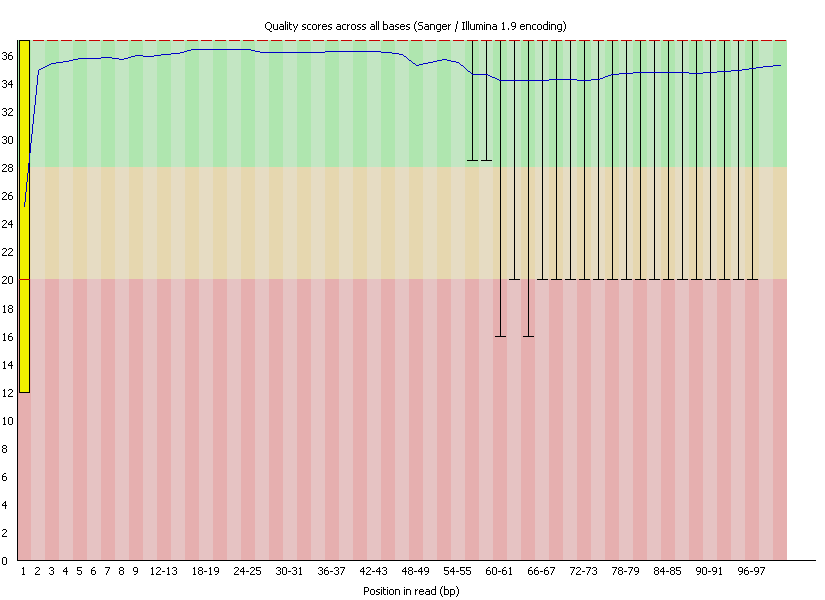

  $$\\[0.15in]$$
  **To mitigate these factors, applied filtering in two steps with the same conditions to all samples in both batches (Sept_5_23 and Oct_4_23).**
- First: removed reads with length shorter than 50 bp, removed Nextera adapters, and removed first bp from paired-end reads.
- Second: removed polyG sequences.

Activate cutadapt 4.4 environment, generate bash script for first step.

```bash
##Activate cutadapt environment with conda##
conda activate cutadaptenv

##create adapter trimming script in present working directory
nano ./trim_adapter.sh
```

Remove reads with length shorter than 50 bp, remove Nextera adapters (sequence [here](https://support-docs.illumina.com/SHARE/AdapterSequences/Content/SHARE/AdapterSeq/Nextera/SequencesNextera_Illumina.htm)), and remove first base pair from paired-end reads with cutadapt 4.4 and 4 computing cores. Repeated the bash script below for Sept_5_23 batch.

```bash
#!/bin/bash

path_fastq="<PATH>/Original_FASTQs/concat_FASTQs"

##Remove reads with less than 50 bp (--minimum-length), remove nextera adapters (-b, -B), and remove first base pair (-u, -U) from paired-end reads using 4 cores##
##write filtered forward R1 fastq (-o) and filtered reverse R2 fastq (-p) in subdirectory (adapter_trimmed)##
for i in `cat ./sample_names`; do
cutadapt --cores=4 --minimum-length 50 -u 1 -U 1 -b CTGTCTCTTATACACATCT -B CTGTCTCTTATACACATCT -o $path_fastq/adapter_trimmed/"$i"_R1_001_trimmed.fastq
-p $path_fastq/adapter_trimmed/"$i"_R2_001_trimmed.fastq $path_fastq/"$i"_R1_001.fastq.gz $path_fastq/"$i"_R2_001.fastq.gz

done
```

Make first step script executable and run script.

```bash
##make adapter trimming script executable
chmod +x ./trim_adapter.sh

##execute adapter trimming script
./trim_adapter.sh
```

Generate bash script for second step to remove polyG sequences.

```bash
##create polyG trimming script in present working directory
nano ./trim_polyG.sh
```

Use filtered FASTQs generated from first step as input and remove polyG sequences. Repeated the bash script below for Sep_5_23 batch.

```bash
#!/bin/bash

path_fastq="<PATH>/Original_FASTQs/concat_FASTQs"

##Remove poly G sequences (-b, -B) from paired-end reads using 4 cores##
##write filtered forward R1 fastq (-o) and filtered reverse R2 fastq (-p) in subdirectory (polyG_trimmed)##
for i in `cat ./sample_names`; do
cutadapt --cores=4 --minimum-length 50 -b GGGGG -B GGGGG -o $path_fastq/polyG_trimmed/"$i"_R1_G_trimmed.fastq -p $path_fastq/polyG_trimmed/"$i"_R2_G_trimmed.fastq $path_fastq/adapter_trimmed/"$i"_R1_001_trimmed.fastq $path_fastq/adapter_trimmed/"$i"_R2_001_trimmed.fastq

done
```

Make second step script executable and run script.

```bash
##make polyG trimming script executable
chmod +x ./trim_polyG.sh

##execute polyG trimming script
./trim_polyG.sh
```

$$\\[0.15in]$$
**After trimming**

Sample Late_nauplii_7 as an example:

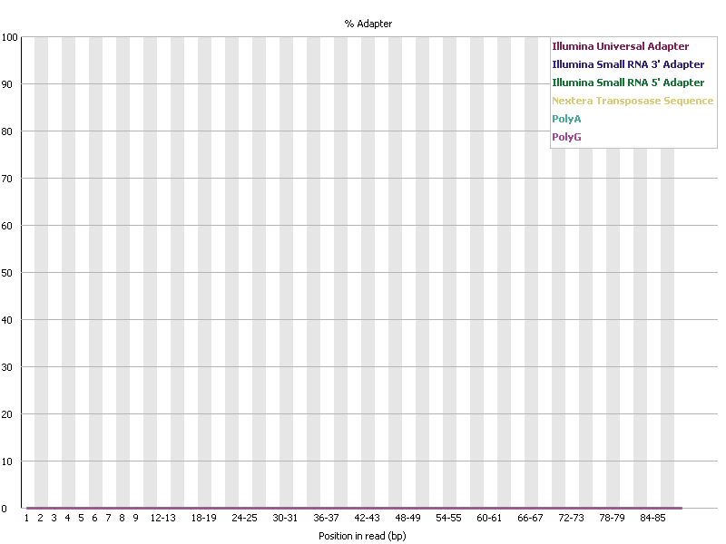

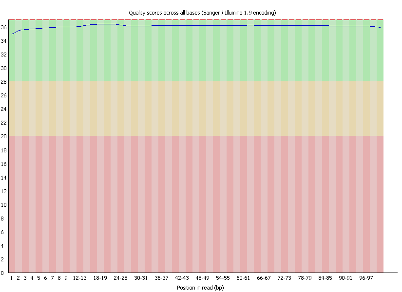

$$\\[0.15in]$$
**Align filtered reads to T.californicus genome (SDv2.2)**

Index T.californicus reference genome with STAR aligner version 2.7.10a manual [here](https://software.cqls.oregonstate.edu/updates/docs/STAR/STARmanual.pdf)

Options used: –runThreadN: # of computing threads to use

–runMode: directs STAR to run genome indices generation job

–genomeDir: path to directory with reference genome

–genomeFastaFiles: reference fasta file (SDv2.2_Genome_NCBI.fasta)

–sjdbGTFfile: file with annotated transcripts in the standard GTF format (in this case annotated transcripts were in GFF3 format SDv2.2_Genes_NCBI.gff, see next option below)

–sjdbGTFtagExonParentTranscript: for GFF3 formatted annotations use ‘Parent’

–sjdbOverhang: Read length minus 1

–genomeSAindexNbases: used to scale down for small genomes (in this case used ‘12’ for the T.californicus 244 megabase genome)

```bash
GENOMEDIR="<PATH>/Reference_Genome"

STAR --runThreadN 4 --runMode genomeGenerate --genomeDir $GENOMEDIR --genomeFastaFiles $GENOMEDIR/SDv2.2_Genome_NCBI.fasta --sjdbGTFfile $GENOMEDIR/SDv2.2_Genes_NCBI.gff --sjdbGTFtagExonParentTranscript Parent --sjdbOverhang 149 --genomeSAindexNbases 12
```

Generate a bash script to automate alignment for each paired-end sample using default options in STAR.

```bash
##create alignment script in present working directory
nano ./alignment.sh
```

Align reads to T.californicus reference genome.

Options used:

–runThreadN: # of computing threads to use

–genomeDir: path to directory with reference genome

–readFilesIn: path to paired-end fastq files

–outFileNamePrefix: path to subdirectory to output log files and aligned SAM files with sample name prefix (e.g., Late_nauplii_7_Aligned.out.sam)

```bash
#!/bin/bash

#Identify reference genome##
GENOMEDIR="<PATH>/Reference_Genome"

##Path to paired-end fastqs##
path_fastq="<PATH>/polyG_trimmed"

##Iterate over unique sample names##
##Align with default STAR options##
for i in `cat ./sample_names`; do
STAR --runThreadN 4 --genomeDir $GENOMEDIR --readFilesIn $path_fastq/"$i"_R1_G_trimmed.fastq $path_fastq/"$i"_R2_G_trimmed.fastq
--outFileNamePrefix <PATH>/Mapping/$i/"$i"_

done
```

Make alignment script executable and run script.

```bash
##make alignment script executable
chmod +x ./alignment.sh

##execute alignment script
./alignment.sh
```

$$\\[0.15in]$$
**Count mapped RNA-seq reads with featureCounts** manual [here](https://subread.sourceforge.net/featureCounts.html)

Generate a bash script to automate generating counts for each sample using featureCounts version 2.0.6.

```bash
##create counts script in present working directory
nano ./counts.sh
```

Options used:

-p: Input data contains paired-end reads.

–countReadPairs: Count fragments instead of reads (i.e., any pair of reads that are properly paired and overlap will be counted as a single fragment rather than as two reads.)

-T: Number of computing threads to use.

-t: Specify the feature type matched in annotation file.

-g: Specify the attribute type used to group features in annotation file.

-s: Indicate if strand-specific read counting should be performed. In this case, used ‘2’ indicating reversely stranded.

-a: Path to gene annotation file.

-o: Name for output file.

```bash
#!/bin/bash

##Path to directory with annotation file##
GENOMEDIR="<PATH>/Reference_Genome"

##Path to aligned SAM files##
path_sam="<PATH>/Mapping"

##Path for output files##
path_counts="<PATH>/featureCounts"

##Iterate over unique sample names##
##Generate counts##
for i in `cat ./sample_names`; do
featureCounts -p --countReadPairs -T 4 -t mRNA -g ID -s 2 -a $GENOMEDIR/SDv2.2_Genes_NCBI.gff -o $path_counts/"$i"_counts.txt $path_sam/$i/"$i"_Aligned.out.sam

done
```

Make counts script executable and run script.

```bash
##Make counts script executable##
chmod +x ./counts.sh

##Execute counts script##
./counts.sh
```

$$\\[0.15in]$$
**Collate counts from each sample (i.e., library) into a single dataframe in R**

Load (or install) R libraries.

```r
library(magrittr)
library(tidyverse)
library(kableExtra)
```

Read in count files from each library and combine into a single dataframe with the 15,577 T_CAL genes as rows and the counts for each library as columns.

```r
##Generate list of all file names (i.e, count and summary files) in the subdirectories for both batches##
all_files<-c(list.files(path = "C:/Users/kevin/Documents/T_californicus/Developmental_RNA_seq/Sept_5_23/counts_G_trimmed_strandedness/", pattern = ".txt", all.files = FALSE, full.names = TRUE), list.files(path = "C:/Users/kevin/Documents/T_californicus/Developmental_RNA_seq/Oct_4_23/counts_G_trimmed_strandedness/", pattern = ".txt", all.files = FALSE, full.names = TRUE))

##Generate list of summary file names in the subdirectories for both batches##
summary_files<-c(list.files(path = "C:/Users/kevin/Documents/T_californicus/Developmental_RNA_seq/Sept_5_23/counts_G_trimmed_strandedness/", pattern = ".summary", all.files = FALSE, full.names = TRUE), list.files(path = "C:/Users/kevin/Documents/T_californicus/Developmental_RNA_seq/Oct_4_23/counts_G_trimmed_strandedness/", pattern = ".summary", all.files = FALSE, full.names = TRUE))

##Use setdiff command to drop summary file names from list leaving only count file names##
count_files<-setdiff(all_files, summary_files)

##Use lapply to read in count files for each sample into a list##
counts_list<-lapply(count_files, read.delim)

##Remove paths and clean up sample names##
count_files <- as.data.frame(count_files) %>%
  separate_wider_delim(count_files, "/", names = c("A", "B", "D", "E", "G", "H", "I", "J", "K")) %>% ##split path and sample name by "/"                                                                                                         delimiter into 9 elements (this is                                                                                                           specific to this path)
  mutate(Sample = paste(I, K, sep = "_")) %>%                       ##combine elements "I" and "K" to combine batch and sample name (e.g.                                                                              Sept_5_23_Adult_female_1)
  select(-c(A, B, D, E, G, H, I, J, K)) %>%                         ##drop remaining path and sample name elements
  mutate(Sample = gsub("_strandedness_counts.txt", "", Sample))     ##remove "_strandedness_counts.txt" suffix##

##Add the names for each sample to the combined list of counts##
names(counts_list)<-count_files$Sample

##For each library, replace column 7 name with "Gene_counts"
new_col_names <- c("Geneid", "Chr", "Start", "End", "Strand", "Length", "Gene_counts")

counts_list <- counts_list %>% lapply(setNames, nm = new_col_names)

##Combine list elements (i.e., libraries) into a single dtaframe

##Use R pakage purr to combine the 16 libraries into a single dataframe and add a column that identifies the library##
gene_counts<-purrr::map_df(counts_list, data.frame, .id = 'library')

##Switch from long to wide format with the command pivot_wider and make a column of counts for each library##
gene_counts %<>%
  pivot_wider(names_from = library, values_from = Gene_counts) %>%
  relocate(Geneid, Chr, Start, End, Strand, Length, Sept_5_23_New_nauplii_3, Sept_5_23_New_nauplii_5, Oct_4_23_New_nauplii_8, Sept_5_23_Late_nauplii_3, Sept_5_23_Late_nauplii_5, Oct_4_23_Late_nauplii_7, Oct_4_23_Late_nauplii_9,
           Sept_5_23_Juvenile_copepodid_3, Sept_5_23_Juvenile_copepodid_6, Oct_4_23_Juvenile_copepodid_7,
           Sept_5_23_Adult_female_1, Sept_5_23_Adult_female_3, Oct_4_23_Adult_female_7,
           Sept_5_23_Adult_male_2, Sept_5_23_Adult_male_3, Oct_4_23_Adult_male_7)

##Visualize top of dataframe
kable(head(gene_counts)) %>% kable_styling() %>% scroll_box(width = "500px")
```

Geneid

Chr

Start

End

Strand

Length

Sept_5_23_New_nauplii_3

Sept_5_23_New_nauplii_5

Oct_4_23_New_nauplii_8

Sept_5_23_Late_nauplii_3

Sept_5_23_Late_nauplii_5

Oct_4_23_Late_nauplii_7

Oct_4_23_Late_nauplii_9

Sept_5_23_Juvenile_copepodid_3

Sept_5_23_Juvenile_copepodid_6

Oct_4_23_Juvenile_copepodid_7

Sept_5_23_Adult_female_1

Sept_5_23_Adult_female_3

Oct_4_23_Adult_female_7

Sept_5_23_Adult_male_2

Sept_5_23_Adult_male_3

Oct_4_23_Adult_male_7

TCAL_15439-PA

Chromosome_12

10812070

10812532

463

1

0

0

0

0

0

1

0

0

0

0

1

0

0

0

0

TCAL_15437-PA

Chromosome_12

10680769

10687762

6994

0

1

4

2

1

3

0

7

4

1

6

13

6

30

19

11

TCAL_15436-PA

Chromosome_12

10667530

10668148

619

32

28

13

3

7

0

1

3

3

1

14

13

24

42

5

28

TCAL_15435-PA

Chromosome_12

10620410

10621244

835

2

3

4

6

4

2

0

0

6

1

9

2

1

11

7

6

TCAL_15434-PA

Chromosome_12

10423883

10425893

2011

46

31

8

141

173

63

60

82

105

48

15

6

9

91

32

79

TCAL_15433-PA

Chromosome_12

10383450

10385210

1761

46

40

36

22

16

12

24

44

16

10

8

9

5

35

8

10

$$\\[0.15in]$$
Save dataframe of collated counts for subsequent analyses.

```r
##Save as an R object
save(gene_counts, file = "C:/Users/kevin/Documents/T_californicus/Developmental_RNA_seq/reproducible/T_cal_developmental_RNA_counts.Rda")

##Write dataframe as a csv file
write.csv(gene_counts, file = "C:/Users/kevin/Documents/T_californicus/Developmental_RNA_seq/reproducible/T_cal_developmental_RNA_counts.csv", row.names = FALSE)
```

$$\\[0.15in]$$

**This completes preprocessing, mapping, and count generation of bulk RNA-seq data for transcriptomic profiling of T. californicus developmental stages.**

Evaluation of expression patterns across developmental stages, statistical analyses, and plotting conducted here.